# STAT 534: Homework 5

Erick Calderon-Morales

Fall 2021

```r
library(mdsr)
library(tidyverse)
library(tidymodels)
library(yardstick)
library(gt)
# for random forest
library(randomForest)
# for calculating sensitivity and specificity
library(caret)
# for ROC curve
library(pROC)
```

*1. Load “titanic data.csv” data downloaded from the Canvas. Use the following codes to preprocess the data:*

```r
filename <- "../../hw5/data/titanic_data.csv"

titanic <-
    read_csv(filename) %>%
        dplyr::select(-c(home.dest, cabin, name, x, ticket))%>%
        filter(embarked != "?")%>%

        mutate(pclass = factor(pclass, levels = c(1, 2, 3),
                               labels = c("Upper", "Middle", "Lower")),

        survived = factor(survived, levels = c(0, 1),
                   labels = c("No", "Yes")),
                   age = as.numeric(age),
                   sex = factor(sex),
                   embarked = factor(embarked)) %>%
        na.omit()

glimpse(titanic)
```

```
Rows: 1,043
Columns: 8
$ pclass   <fct> Upper, Upper, Upper, Upper, Upper, Upper, Upper, Upper, Upper…
$ survived <fct> Yes, Yes, No, No, No, Yes, Yes, No, Yes, No, No, Yes, Yes, Ye…
$ sex      <fct> female, male, female, male, female, male, female, male, femal…
$ age      <dbl> 29.0000, 0.9167, 2.0000, 30.0000, 25.0000, 48.0000, 63.0000, …
$ sibsp    <dbl> 0, 1, 1, 1, 1, 0, 1, 0, 2, 0, 1, 1, 0, 0, 0, 0, 0, 0, 0, 1, 1…
$ parch    <dbl> 0, 2, 2, 2, 2, 0, 0, 0, 0, 0, 0, 0, 0, 0, 0, 1, 1, 0, 0, 1, 1…
$ fare     <dbl> 211.3375, 151.5500, 151.5500, 151.5500, 151.5500, 26.5500, 77…
$ embarked <fct> S, S, S, S, S, S, S, S, S, C, C, C, C, S, S, C, C, C, C, S, S…
```

*Count total of No and Yes in the dataset*

How do I know if the dataset is imbalanced?

```r
titanic %>%
  group_by(survived) %>%
  count() %>%
  mutate(percent = (n/nrow(titanic)*100))
```

```
# A tibble: 2 × 3
# Groups:   survived [2]
  survived     n percent
  <fct>    <int>   <dbl>
1 No         618    59.3
2 Yes        425    40.7
```

*(a) Separate the training and testing datasets using 80%/20% splitting. (5 points)*

```r
# Training testing/split
set.seed(666)

n <- nrow(titanic)

# Split data 80/20
index <- sample(1:nrow(titanic),(nrow(titanic)*.80)/1)

# Get training data
training_data <- titanic[index,]

# Get testing data
testing_data <- titanic[-index,]

# Double check
(nrow(training_data)*100)/nrow(titanic)
```

```
[1] 79.96165
```

```r
(nrow(testing_data)*100)/nrow(titanic)
```

```
[1] 20.03835
```

*(b) Fit a logistic regression model to predict survived using all other available variables. Here are the formula:*

$$survived\ \sim\ pclass + sex + age + sibsp + parch + fare + embarked$$

```r
# Model formula
model <- as.formula(survived ~ pclass + sex + age + sibsp + parch + fare +
                        embarked)
```

```r
# Multivariate logistic regression
model_logit <-
    # Class
    logistic_reg(mode = "classification") %>%

    # Engine
    set_engine("glm") %>%

    # Fit formula
    fit(model,
        data = training_data)
```

*(b.1) Please show the confusion matrix for the training data and calculate the training accuracy rate. (10 points)*

```r
# Get training predictions
pred_train_logit <-
  training_data %>%
      bind_cols(predict(model_logit, new_data = training_data)) %>%
      rename(survived_pred = .pred_class)

# Confusion matrix
pred_train_logit %>%
  conf_mat(truth = survived, estimate = survived_pred)
```

```
          Truth
Prediction  No Yes
       No  427  97
       Yes  73 237
```

```r
# Training accuracy rate
accuracy(pred_train_logit, survived, survived_pred)
```

```
# A tibble: 1 × 3
  .metric  .estimator .estimate
  <chr>    <chr>          <dbl>
1 accuracy binary         0.796
```

**The confusion matrix shows that the logistic regression model in the train dataset classified correctly as No 427 out of 524 observations while it classified correctly as Yes 237 out of 310 observations**

*(c) If we want to fit a random forests model using the same formula, how to set the parameter mtry (the number of candidates for splitting varibles)? (5 points)*

**mtry for the random forest is defined as $\sqrt{predictors}$**

*(d) Fit a random forests model and show the confusion matrix for the training data and calculate the training accuracy rate. You can set the number of trees as 201. (10 points).*

```r
random_forest_titanic <- randomForest (model, data = training_data,

                                       # mtry = squared of p'
                                       #  -1 = remove response variable
                                       mtry =
                                         round(sqrt(ncol(training_data) - 1),0),

                                       # Number of trees
                                       ntree = 201,

                                       # Which variables have the greatest
                                       # importance?
                                       importance = TRUE)
```

```r
# Get training predictions
pred_train_random_forest <-
  training_data %>%
      bind_cols(predict(random_forest_titanic, new_data = titanic[index,])) %>%
      rename(survived_pred_random_forest = ...9)

# Confusion matrix
pred_train_random_forest %>%
  conf_mat(truth = survived, estimate = survived_pred_random_forest)
```

```
          Truth
Prediction  No Yes
       No  436 103
       Yes  64 231
```

```r
# Training accuracy rate
accuracy(pred_train_random_forest, survived, survived_pred_random_forest)
```

```
# A tibble: 1 × 3
  .metric  .estimator .estimate
  <chr>    <chr>          <dbl>
1 accuracy binary         0.800
```

*(e) Find the most important explanatory variable of the random forests model. (5 points)*

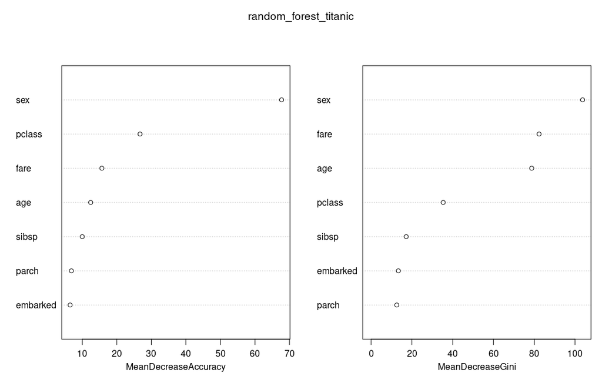

```r
varImpPlot(random_forest_titanic)
```

*(f) Find the testing accuracy rate of the two models. (5 points)*

```r
# Get test predictions for logistic regression model
pred_test_logit <-
  testing_data %>%
      bind_cols(predict(model_logit, new_data = testing_data)) %>%
      rename(survived_pred_test = .pred_class)
```

```r
# Test accuracy rate for logistic regression model
accuracy(pred_test_logit, survived, survived_pred_test)
```

```
# A tibble: 1 × 3
  .metric  .estimator .estimate
  <chr>    <chr>          <dbl>
1 accuracy binary         0.761
```

```r
# Get test predictions for random forest
pred_test_random_forest <-
  testing_data  %>%
      bind_cols(predict(random_forest_titanic, newdata = titanic[-index,], type = "class")) %>%
      rename(survived_pred_random_forest_test = ...9)
```

```r
# Test accuracy rate for random forest
accuracy(pred_test_random_forest, survived, survived_pred_random_forest_test)
```

```
# A tibble: 1 × 3
  .metric  .estimator .estimate
  <chr>    <chr>          <dbl>
1 accuracy binary         0.789
```

*(g) Which accuracy should we use to compare the two models? What’s your conclusion? (5 points)*

the testing

```r
# Get probs for yes and no
probs <- predict(random_forest_titanic, newdata = titanic[-index,], type = "prob")
pred <- predict(random_forest_titanic, newdata = titanic[-index,])

head(as.data.frame(cbind(probs,pred)))
```

```
           No       Yes pred
1 0.338308458 0.6616915    2
2 0.049751244 0.9502488    2
3 0.029850746 0.9701493    2
4 0.547263682 0.4527363    1
5 0.019900498 0.9800995    2
6 0.004975124 0.9950249    2
```

```r
testing_data$random_forest_prob_no <- probs[,1]
testing_data$random_forest_prob_yes <- probs[,2]

testing_data$random_forest_pred <- predict(random_forest_titanic,
                                           newdata = titanic[-index,])
```

**Sensitivity**

The sensitivity of the model is the rate that the event of interest is predicted correctly for all samples having the event. (True positive rate) It measures the accuracy in the event population

```r
# Class Yes will be used as the event of interest
sensitivity(data = testing_data$random_forest_pred,
            reference = testing_data$survived,
            positive = "Yes")
```

```
[1] 0.6813187
```

**Specificity**

```r
specificity(data = testing_data$random_forest_pred,
            reference = testing_data$survived,
            negative = "No")
```

```
[1] 0.8728814
```

**False-positive rate**

```r
1 - (specificity(data = testing_data$random_forest_pred,
            reference = testing_data$survived,
            negative = "No"))
```

```
[1] 0.1271186
```

```r
roc_curve <- roc(response  = testing_data$survived,
                 predictor = testing_data$random_forest_prob_no,
                 levels    = rev(levels(testing_data$survived)))
```

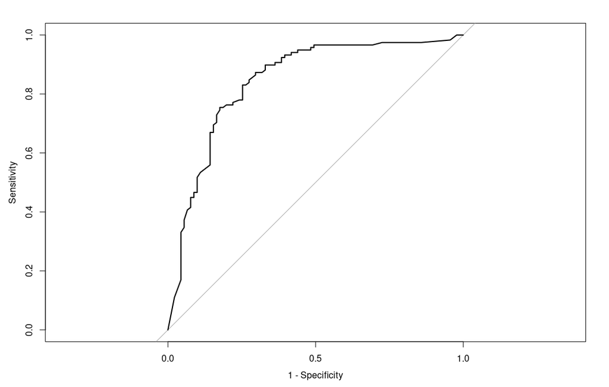

```r
plot(roc_curve,legacy.axes = TRUE, xlim = c(1,0))
```